# Gathering Data

# Cleaning

```python
#Before cleaning make the copies of the original dataframes
twitter_archive_clean=df_twitter_archive.copy()
images_clean=df_image_predictions.copy()
tweets_clean=df_tweets.copy()
```

## Define

1. convert the datatype of timestamp to datetime and remove the +00000

## code

```python
#check the code
twitter_archive_clean.timestamp.head()
```

```
0    2017-08-01 16:23:56 +0000
1    2017-08-01 00:17:27 +0000
2    2017-07-31 00:18:03 +0000
3    2017-07-30 15:58:51 +0000
4    2017-07-29 16:00:24 +0000
Name: timestamp, dtype: object
```

```python
#Removing the last +00000
twitter_archive_clean.timestamp=twitter_archive_clean.timestamp.str[:-6]
```

```python
#Converting to datetime
twitter_archive_clean['timestamp']=pd.to_datetime(twitter_archive_clean['timestamp'])
```

## Test

```python
twitter_archive_clean.timestamp.sample(5)
```

```
2159   2015-11-25 17:40:53
1227   2016-03-27 02:05:49
1153   2016-04-28 16:52:08
2268   2015-11-20 01:39:42
383    2017-02-02 17:00:17
Name: timestamp, dtype: datetime64[ns]
```

## Define

1. Drop the unnecessary in_reply_to_status_id,in_reply_to_user_id,retweeted_status_id,retweeted_status_user_id,retweeted_status_timestamp

## Code

```python
#dropping unwanted columns
twitter_archive_clean.drop(['in_reply_to_status_id','in_reply_to_user_id','retweeted_status_id','retweeted_status_user_id','retweeted_status_timestamp'],axis=1,inplace=True)
```

## Test

```python
twitter_archive_clean.info()
```

```
<class 'pandas.core.frame.DataFrame'>
RangeIndex: 2356 entries, 0 to 2355
Data columns (total 12 columns):
 #   Column              Non-Null Count  Dtype
---  ------              --------------  -----
 0   tweet_id            2356 non-null   int64
 1   timestamp           2356 non-null   datetime64[ns]
 2   source              2356 non-null   object
 3   text                2356 non-null   object
 4   expanded_urls       2297 non-null   object
 5   rating_numerator    2356 non-null   int64
 6   rating_denominator  2356 non-null   int64
 7   name                2356 non-null   object
 8   doggo               2356 non-null   object
 9   floofer             2356 non-null   object
 10  pupper              2356 non-null   object
 11  puppo               2356 non-null   object
dtypes: datetime64[ns](1), int64(3), object(8)
memory usage: 221.0+ KB
```

## Define

1. Merge the three dataframes into a single one as they belong to the same data unit

## code

```python
#Merging all three dataframes into one
df_dog_tweets=twitter_archive_clean.merge(images_clean,on='tweet_id',how='left').merge(tweets_clean,on='tweet_id',how='left')
```

## Test

```python
df_dog_tweets
```

|  | tweet_id | timestamp | source | text | expanded_urls | rating_numerator | rating_denominator | name | doggo | floofer | ... | p1_conf | p1_dog | p2 | p2_conf | p2_dog | p3 | p3_conf | p3_dog | favorites | retweet_count |
| --- | --- | --- | --- | --- | --- | --- | --- | --- | --- | --- | --- | --- | --- | --- | --- | --- | --- | --- | --- | --- | --- |
| 0 | 892420643555336193 | 2017-08-01 16:23:56 | <a href="http://twitter.com/download/iphone" r... | This is Phineas. He's a mystical boy. Only eve... | https://twitter.com/dog_rates/status/892420643... | 13 | 10 | Phineas | None | None | ... | 0.097049 | False | bagel | 0.085851 | False | banana | 0.076110 | False | 35927.0 | 7630.0 |
| 1 | 892177421306343426 | 2017-08-01 00:17:27 | <a href="http://twitter.com/download/iphone" r... | This is Tilly. She's just checking pup on you.... | https://twitter.com/dog_rates/status/892177421... | 13 | 10 | Tilly | None | None | ... | 0.323581 | True | Pekinese | 0.090647 | True | papillon | 0.068957 | True | 30990.0 | 5643.0 |
| 2 | 891815181378084864 | 2017-07-31 00:18:03 | <a href="http://twitter.com/download/iphone" r... | This is Archie. He is a rare Norwegian Pouncin... | https://twitter.com/dog_rates/status/891815181... | 12 | 10 | Archie | None | None | ... | 0.716012 | True | malamute | 0.078253 | True | kelpie | 0.031379 | True | 23316.0 | 3740.0 |
| 3 | 891689557279858688 | 2017-07-30 15:58:51 | <a href="http://twitter.com/download/iphone" r... | This is Darla. She commenced a snooze mid meal... | https://twitter.com/dog_rates/status/891689557... | 13 | 10 | Darla | None | None | ... | 0.170278 | False | Labrador_retriever | 0.168086 | True | spatula | 0.040836 | False | 39190.0 | 7791.0 |
| 4 | 891327558926688256 | 2017-07-29 16:00:24 | <a href="http://twitter.com/download/iphone" r... | This is Franklin. He would like you to stop ca... | https://twitter.com/dog_rates/status/891327558... | 12 | 10 | Franklin | None | None | ... | 0.555712 | True | English_springer | 0.225770 | True | German_short-haired_pointer | 0.175219 | True | 37430.0 | 8393.0 |
| ... | ... | ... | ... | ... | ... | ... | ... | ... | ... | ... | ... | ... | ... | ... | ... | ... | ... | ... | ... | ... | ... |
| 2351 | 666049248165822465 | 2015-11-16 00:24:50 | <a href="http://twitter.com/download/iphone" r... | Here we have a 1949 1st generation vulpix. Enj... | https://twitter.com/dog_rates/status/666049248... | 5 | 10 | None | None | None | ... | 0.560311 | True | Rottweiler | 0.243682 | True | Doberman | 0.154629 | True | 96.0 | 40.0 |
| 2352 | 666044226329800704 | 2015-11-16 00:04:52 | <a href="http://twitter.com/download/iphone" r... | This is a purebred Piers Morgan. Loves to Netf... | https://twitter.com/dog_rates/status/666044226... | 6 | 10 | a | None | None | ... | 0.408143 | True | redbone | 0.360687 | True | miniature_pinscher | 0.222752 | True | 269.0 | 130.0 |
| 2353 | 666033412701032449 | 2015-11-15 23:21:54 | <a href="http://twitter.com/download/iphone" r... | Here is a very happy pup. Big fan of well-main... | https://twitter.com/dog_rates/status/666033412... | 9 | 10 | a | None | None | ... | 0.596461 | True | malinois | 0.138584 | True | bloodhound | 0.116197 | True | 111.0 | 41.0 |
| 2354 | 666029285002620928 | 2015-11-15 23:05:30 | <a href="http://twitter.com/download/iphone" r... | This is a western brown Mitsubishi terrier. Up... | https://twitter.com/dog_rates/status/666029285... | 7 | 10 | a | None | None | ... | 0.506826 | True | miniature_pinscher | 0.074192 | True | Rhodesian_ridgeback | 0.072010 | True | 120.0 | 42.0 |
| 2355 | 666020888022790149 | 2015-11-15 22:32:08 | <a href="http://twitter.com/download/iphone" r... | Here we have a Japanese Irish Setter. Lost eye... | https://twitter.com/dog_rates/status/666020888... | 8 | 10 | None | None | None | ... | 0.465074 | True | collie | 0.156665 | True | Shetland_sheepdog | 0.061428 | True | 2394.0 | 459.0 |

2356 rows × 25 columns

## Define

1. Correcting the dog names and making them None wherever necessary

## code

```python
df_dog_tweets.name.unique()
```

```
array(['Phineas', 'Tilly', 'Archie', 'Darla', 'Franklin', 'None', 'Jax',
       'Zoey', 'Cassie', 'Koda', 'Bruno', 'Ted', 'Stuart', 'Oliver',
       'Jim', 'Zeke', 'Ralphus', 'Canela', 'Gerald', 'Jeffrey', 'such',
       'Maya', 'Mingus', 'Derek', 'Roscoe', 'Waffles', 'Jimbo', 'Maisey',
       'Lilly', 'Earl', 'Lola', 'Kevin', 'Yogi', 'Noah', 'Bella',
       'Grizzwald', 'Rusty', 'Gus', 'Stanley', 'Alfy', 'Koko', 'Rey',
       'Gary', 'a', 'Elliot', 'Louis', 'Jesse', 'Romeo', 'Bailey',
       'Duddles', 'Jack', 'Emmy', 'Steven', 'Beau', 'Snoopy', 'Shadow',
       'Terrance', 'Aja', 'Penny', 'Dante', 'Nelly', 'Ginger', 'Benedict',
       'Venti', 'Goose', 'Nugget', 'Cash', 'Coco', 'Jed', 'Sebastian',
       'Walter', 'Sierra', 'Monkey', 'Harry', 'Kody', 'Lassie', 'Rover',
       'Napolean', 'Dawn', 'Boomer', 'Cody', 'Rumble', 'Clifford',
       'quite', 'Dewey', 'Scout', 'Gizmo', 'Cooper', 'Harold', 'Shikha',
       'Jamesy', 'Lili', 'Sammy', 'Meatball', 'Paisley', 'Albus',
       'Neptune', 'Quinn', 'Belle', 'Zooey', 'Dave', 'Jersey', 'Hobbes',
       'Burt', 'Lorenzo', 'Carl', 'Jordy', 'Milky', 'Trooper', 'Winston',
       'Sophie', 'Wyatt', 'Rosie', 'Thor', 'Oscar', 'Luna', 'Callie',
       'Cermet', 'George', 'Marlee', 'Arya', 'Einstein', 'Alice',
       'Rumpole', 'Benny', 'Aspen', 'Jarod', 'Wiggles', 'General',
       'Sailor', 'Astrid', 'Iggy', 'Snoop', 'Kyle', 'Leo', 'Riley',
       'Gidget', 'Noosh', 'Odin', 'Jerry', 'Charlie', 'Georgie', 'Rontu',
       'Cannon', 'Furzey', 'Daisy', 'Tuck', 'Barney', 'Vixen', 'Jarvis',
       'Mimosa', 'Pickles', 'Bungalo', 'Brady', 'Margo', 'Sadie', 'Hank',
       'Tycho', 'Stephan', 'Indie', 'Winnie', 'Bentley', 'Ken', 'Max',
       'Maddie', 'Pipsy', 'Monty', 'Sojourner', 'Odie', 'Arlo', 'Sunny',
       'Vincent', 'Lucy', 'Clark', 'Mookie', 'Meera', 'Buddy', 'Ava',
       'Rory', 'Eli', 'Ash', 'Tucker', 'Tobi', 'Chester', 'Wilson',
       'Sunshine', 'Lipton', 'Gabby', 'Bronte', 'Poppy', 'Rhino',
       'Willow', 'not', 'Orion', 'Eevee', 'Smiley', 'Logan', 'Moreton',
       'Klein', 'Miguel', 'Emanuel', 'Kuyu', 'Dutch', 'Pete', 'Scooter',
       'Reggie', 'Kyro', 'Samson', 'Loki', 'Mia', 'Malcolm', 'Dexter',
       'Alfie', 'Fiona', 'one', 'Mutt', 'Bear', 'Doobert', 'Beebop',
       'Alexander', 'Sailer', 'Brutus', 'Kona', 'Boots', 'Ralphie',
       'Phil', 'Cupid', 'Pawnd', 'Pilot', 'Ike', 'Mo', 'Toby', 'Sweet',
       'Pablo', 'Nala', 'Balto', 'Crawford', 'Gabe', 'Mattie', 'Jimison',
       'Hercules', 'Duchess', 'Harlso', 'Sampson', 'Sundance', 'Luca',
       'Flash', 'Finn', 'Peaches', 'Howie', 'Jazzy', 'Anna', 'Bo',
       'Seamus', 'Wafer', 'Chelsea', 'Tom', 'Moose', 'Florence', 'Autumn',
       'Dido', 'Eugene', 'Herschel', 'Strudel', 'Tebow', 'Chloe', 'Betty',
       'Timber', 'Binky', 'Dudley', 'Comet', 'Larry', 'Levi', 'Akumi',
```

[output cut: 88 more lines]

```
       'Anthony', 'Holly', 'Jett', 'Amy', 'Sage', 'Andy', 'Mason',
       'Trigger', 'Antony', 'Creg', 'Traviss', 'Gin', 'Jeffrie', 'Danny',
       'Ester', 'Pluto', 'Bloo', 'Edd', 'Willy', 'Herb', 'Damon',
       'Peanut', 'Nigel', 'Butters', 'Sandra', 'Fabio', 'Randall', 'Liam',
       'Tommy', 'Ben', 'Raphael', 'Julio', 'Andru', 'Kloey', 'Shawwn',
       'Skye', 'Kollin', 'Ronduh', 'Billl', 'Saydee', 'Dug', 'Tessa',
       'Sully', 'Kirk', 'Ralf', 'Clarq', 'Jaspers', 'Samsom', 'Harrison',
       'Chaz', 'Jeremy', 'Jaycob', 'Lambeau', 'Ruffles', 'Amélie', 'Bobb',
       'Banditt', 'Kevon', 'Winifred', 'Hanz', 'Churlie', 'Zeek',
       'Timofy', 'Maks', 'Jomathan', 'Kallie', 'Marvin', 'Spark',
       'Gòrdón', 'Jo', 'DayZ', 'Jareld', 'Torque', 'Ron', 'Skittles',
       'Cleopatricia', 'Erik', 'Stu', 'Tedrick', 'Filup', 'Kial',
       'Naphaniel', 'Dook', 'Hall', 'Philippe', 'Biden', 'Fwed',
       'Genevieve', 'Joshwa', 'Bradlay', 'Clybe', 'Keet', 'Carll',
       'Jockson', 'Josep', 'Lugan', 'Christoper'], dtype=object)
```

By observation we can see that all the incorrect names are lowercase. This will make the operation easy

```python
#writing a function to change the dog names
n=[]
def dog_name(name):
    if name['name'][0].islower() == True:
        n.append('None')
    else:
        n.append(name['name'])
df_dog_tweets.apply(dog_name, axis=1)
df_dog_tweets['name'] = n
```

## Test

```python
df_dog_tweets.name.unique()
```

```
array(['Phineas', 'Tilly', 'Archie', 'Darla', 'Franklin', 'None', 'Jax',
       'Zoey', 'Cassie', 'Koda', 'Bruno', 'Ted', 'Stuart', 'Oliver',
       'Jim', 'Zeke', 'Ralphus', 'Canela', 'Gerald', 'Jeffrey', 'Maya',
       'Mingus', 'Derek', 'Roscoe', 'Waffles', 'Jimbo', 'Maisey', 'Lilly',
       'Earl', 'Lola', 'Kevin', 'Yogi', 'Noah', 'Bella', 'Grizzwald',
       'Rusty', 'Gus', 'Stanley', 'Alfy', 'Koko', 'Rey', 'Gary', 'Elliot',
       'Louis', 'Jesse', 'Romeo', 'Bailey', 'Duddles', 'Jack', 'Emmy',
       'Steven', 'Beau', 'Snoopy', 'Shadow', 'Terrance', 'Aja', 'Penny',
       'Dante', 'Nelly', 'Ginger', 'Benedict', 'Venti', 'Goose', 'Nugget',
       'Cash', 'Coco', 'Jed', 'Sebastian', 'Walter', 'Sierra', 'Monkey',
       'Harry', 'Kody', 'Lassie', 'Rover', 'Napolean', 'Dawn', 'Boomer',
       'Cody', 'Rumble', 'Clifford', 'Dewey', 'Scout', 'Gizmo', 'Cooper',
       'Harold', 'Shikha', 'Jamesy', 'Lili', 'Sammy', 'Meatball',
       'Paisley', 'Albus', 'Neptune', 'Quinn', 'Belle', 'Zooey', 'Dave',
       'Jersey', 'Hobbes', 'Burt', 'Lorenzo', 'Carl', 'Jordy', 'Milky',
       'Trooper', 'Winston', 'Sophie', 'Wyatt', 'Rosie', 'Thor', 'Oscar',
       'Luna', 'Callie', 'Cermet', 'George', 'Marlee', 'Arya', 'Einstein',
       'Alice', 'Rumpole', 'Benny', 'Aspen', 'Jarod', 'Wiggles',
       'General', 'Sailor', 'Astrid', 'Iggy', 'Snoop', 'Kyle', 'Leo',
       'Riley', 'Gidget', 'Noosh', 'Odin', 'Jerry', 'Charlie', 'Georgie',
       'Rontu', 'Cannon', 'Furzey', 'Daisy', 'Tuck', 'Barney', 'Vixen',
       'Jarvis', 'Mimosa', 'Pickles', 'Bungalo', 'Brady', 'Margo',
       'Sadie', 'Hank', 'Tycho', 'Stephan', 'Indie', 'Winnie', 'Bentley',
       'Ken', 'Max', 'Maddie', 'Pipsy', 'Monty', 'Sojourner', 'Odie',
       'Arlo', 'Sunny', 'Vincent', 'Lucy', 'Clark', 'Mookie', 'Meera',
       'Buddy', 'Ava', 'Rory', 'Eli', 'Ash', 'Tucker', 'Tobi', 'Chester',
       'Wilson', 'Sunshine', 'Lipton', 'Gabby', 'Bronte', 'Poppy',
       'Rhino', 'Willow', 'Orion', 'Eevee', 'Smiley', 'Logan', 'Moreton',
       'Klein', 'Miguel', 'Emanuel', 'Kuyu', 'Dutch', 'Pete', 'Scooter',
       'Reggie', 'Kyro', 'Samson', 'Loki', 'Mia', 'Malcolm', 'Dexter',
       'Alfie', 'Fiona', 'Mutt', 'Bear', 'Doobert', 'Beebop', 'Alexander',
       'Sailer', 'Brutus', 'Kona', 'Boots', 'Ralphie', 'Phil', 'Cupid',
       'Pawnd', 'Pilot', 'Ike', 'Mo', 'Toby', 'Sweet', 'Pablo', 'Nala',
       'Balto', 'Crawford', 'Gabe', 'Mattie', 'Jimison', 'Hercules',
       'Duchess', 'Harlso', 'Sampson', 'Sundance', 'Luca', 'Flash',
       'Finn', 'Peaches', 'Howie', 'Jazzy', 'Anna', 'Bo', 'Seamus',
       'Wafer', 'Chelsea', 'Tom', 'Moose', 'Florence', 'Autumn', 'Dido',
       'Eugene', 'Herschel', 'Strudel', 'Tebow', 'Chloe', 'Betty',
       'Timber', 'Binky', 'Dudley', 'Comet', 'Larry', 'Levi', 'Akumi',
       'Titan', 'Olivia', 'Alf', 'Oshie', 'Bruce', 'Chubbs', 'Sky',
```

[output cut: 85 more lines]

```
       'Sage', 'Andy', 'Mason', 'Trigger', 'Antony', 'Creg', 'Traviss',
       'Gin', 'Jeffrie', 'Danny', 'Ester', 'Pluto', 'Bloo', 'Edd',
       'Willy', 'Herb', 'Damon', 'Peanut', 'Nigel', 'Butters', 'Sandra',
       'Fabio', 'Randall', 'Liam', 'Tommy', 'Ben', 'Raphael', 'Julio',
       'Andru', 'Kloey', 'Shawwn', 'Skye', 'Kollin', 'Ronduh', 'Billl',
       'Saydee', 'Dug', 'Tessa', 'Sully', 'Kirk', 'Ralf', 'Clarq',
       'Jaspers', 'Samsom', 'Harrison', 'Chaz', 'Jeremy', 'Jaycob',
       'Lambeau', 'Ruffles', 'Amélie', 'Bobb', 'Banditt', 'Kevon',
       'Winifred', 'Hanz', 'Churlie', 'Zeek', 'Timofy', 'Maks',
       'Jomathan', 'Kallie', 'Marvin', 'Spark', 'Gòrdón', 'Jo', 'DayZ',
       'Jareld', 'Torque', 'Ron', 'Skittles', 'Cleopatricia', 'Erik',
       'Stu', 'Tedrick', 'Filup', 'Kial', 'Naphaniel', 'Dook', 'Hall',
       'Philippe', 'Biden', 'Fwed', 'Genevieve', 'Joshwa', 'Bradlay',
       'Clybe', 'Keet', 'Carll', 'Jockson', 'Josep', 'Lugan',
       'Christoper'], dtype=object)
```

## Define

1. Change the datatype of tweet_id to object

## Code

```python
#converting the datatype of tweetid to object
df_dog_tweets.tweet_id=df_dog_tweets.tweet_id.astype(object)
```

## Test

```python
df_dog_tweets.info()
```

```
<class 'pandas.core.frame.DataFrame'>
Int64Index: 2356 entries, 0 to 2355
Data columns (total 25 columns):
 #   Column              Non-Null Count  Dtype
---  ------              --------------  -----
 0   tweet_id            2356 non-null   object
 1   timestamp           2356 non-null   datetime64[ns]
 2   source              2356 non-null   object
 3   text                2356 non-null   object
 4   expanded_urls       2297 non-null   object
 5   rating_numerator    2356 non-null   int64
 6   rating_denominator  2356 non-null   int64
 7   name                2356 non-null   object
 8   doggo               2356 non-null   object
 9   floofer             2356 non-null   object
```

[output cut: 17 more lines]

## Define

1. Melt the dog stages into one column

## Code

```python
df_dog_tweets.columns
```

```
Index(['tweet_id', 'timestamp', 'source', 'text', 'expanded_urls',
       'rating_numerator', 'rating_denominator', 'name', 'doggo', 'floofer',
       'pupper', 'puppo', 'jpg_url', 'img_num', 'p1', 'p1_conf', 'p1_dog',
       'p2', 'p2_conf', 'p2_dog', 'p3', 'p3_conf', 'p3_dog', 'favorites',
       'retweet_count'],
      dtype='object')
```

```python
#Melting the dog stages into one column
df_dog_tweets=pd.melt(df_dog_tweets,id_vars=['tweet_id', 'timestamp', 'source', 'text', 'expanded_urls',
       'rating_numerator', 'rating_denominator', 'name', 'jpg_url', 'img_num', 'p1', 'p1_conf', 'p1_dog',
       'p2', 'p2_conf', 'p2_dog', 'p3', 'p3_conf', 'p3_dog', 'favorites',
       'retweet_count'],value_vars = ['doggo', 'floofer', 'pupper', 'puppo'],var_name='dog_type')
```

```python
df_dog_tweets.drop('value',axis=1,inplace=True)
```

```python
df_dog_tweets.sample(5)
```

|  | tweet_id | timestamp | source | text | expanded_urls | rating_numerator | rating_denominator | name | jpg_url | img_num | ... | p1_dog | p2 | p2_conf | p2_dog | p3 | p3_conf | p3_dog | favorites | retweet_count | dog_type |
| --- | --- | --- | --- | --- | --- | --- | --- | --- | --- | --- | --- | --- | --- | --- | --- | --- | --- | --- | --- | --- | --- |
| 7750 | 788552643979468800 | 2016-10-19 01:29:35 | <a href="http://twitter.com/download/iphone" r... | RT @dog_rates: Say hello to mad pupper. You kn... | https://vine.co/v/iEggaEOiLO3,https://vine.co/... | 13 | 10 | None | NaN | NaN | ... | NaN | NaN | NaN | NaN | NaN | NaN | NaN | 0.0 | 7267.0 | puppo |
| 6732 | 672095186491711488 | 2015-12-02 16:49:14 | <a href="http://twitter.com/download/iphone" r... | This is Tuco. That's the toast that killed his... | https://twitter.com/dog_rates/status/672095186... | 9 | 10 | Tuco | https://pbs.twimg.com/media/CVPDAR9XIAAm8QB.jpg | 1.0 | ... | True | French_bulldog | 0.140796 | True | bull_mastiff | 0.044681 | True | 953.0 | 351.0 | pupper |
| 9216 | 669749430875258880 | 2015-11-26 05:28:02 | <a href="http://twitter.com/download/iphone" r... | Say hello to Clarence. Clarence thought he saw... | https://twitter.com/dog_rates/status/669749430... | 8 | 10 | Clarence | https://pbs.twimg.com/media/CUttjYtWcAAdPgI.jpg | 1.0 | ... | False | toilet_seat | 0.109420 | False | paper_towel | 0.105664 | False | 250.0 | 63.0 | puppo |
| 4509 | 669661792646373376 | 2015-11-25 23:39:47 | <a href="http://twitter.com/download/iphone" r... | This is a brave dog. Excellent free climber. T... | https://twitter.com/dog_rates/status/669661792... | 5 | 10 | None | https://pbs.twimg.com/media/CUsd2TfWwAAmdjb.jpg | 1.0 | ... | False | Siamese_cat | 0.148263 | False | hamster | 0.116374 | False | 773.0 | 410.0 | floofer |
| 4035 | 682032003584274432 | 2015-12-30 02:54:35 | <a href="http://twitter.com/download/iphone" r... | This is Ulysses. He likes holding hands and hi... | https://twitter.com/dog_rates/status/682032003... | 11 | 10 | Ulysses | https://pbs.twimg.com/media/CXcQfUNUQAEwFoQ.jpg | 1.0 | ... | True | groenendael | 0.000676 | True | miniature_pinscher | 0.000211 | True | 6490.0 | 1971.0 | floofer |

5 rows × 22 columns

```python
#It is observed that duplicate values are created drop the duplicated
df_dog_tweets=df_dog_tweets.drop_duplicates('tweet_id')
df_dog_tweets.shape
```

```
(2356, 22)
```

## Define

1. Correct the denominator values. Every denominator has to be 10

## Code

```python
#Assigning all values of denominators as 10
df_dog_tweets.rating_denominator=10
```

## Test

```python
df_dog_tweets.rating_denominator.unique()
```

```
array([10], dtype=int64)
```

```python
df_dog_tweets.query('rating_denominator==10').count()
```

```
tweet_id              2356
timestamp             2356
source                2356
text                  2356
expanded_urls         2297
rating_numerator      2356
rating_denominator    2356
name                  2356
jpg_url               2075
img_num               2075
p1                    2075
p1_conf               2075
p1_dog                2075
p2                    2075
p2_conf               2075
p2_dog                2075
p3                    2075
p3_conf               2075
p3_dog                2075
favorites             2331
retweet_count         2331
dog_type              2356
dtype: int64
```

## Define

1. Extract the source of the tweets from the anchor tag

## Code

```python
#checking for the source types
df_dog_tweets.source.unique()
```

```
array(['<a href="http://twitter.com/download/iphone" rel="nofollow">Twitter for iPhone</a>',
       '<a href="http://twitter.com" rel="nofollow">Twitter Web Client</a>',
       '<a href="http://vine.co" rel="nofollow">Vine - Make a Scene</a>',
       '<a href="https://about.twitter.com/products/tweetdeck" rel="nofollow">TweetDeck</a>'],
      dtype=object)
```

```python
#using regular expressions to extract the source from the tags
df_dog_tweets.source=df_dog_tweets.source.str.extract(r'>(.+?)<', expand=False)
```

## Test

```python
df_dog_tweets.source.unique()
```

```
array(['Twitter for iPhone', 'Twitter Web Client', 'Vine - Make a Scene',
       'TweetDeck'], dtype=object)
```

## Define

1. Some dog predictions in p1 makes no sense so compile the actual dog breed from p1,p2 and p3 into one single column to derive the actual breed of the dog

## Code

```python
#write a function to compile the dog breeds
l=[]
def dog_breed(breed):
    if breed['p1_dog']==True:
        l.append(breed['p1'])
    elif breed['p2_dog']==True:
        l.append(breed['p2'])
    elif breed['p3_dog']==True:
        l.append(breed['p3'])
    else:
        l.append('unknown')
df_dog_tweets.apply(dog_breed,axis=1)
df_dog_tweets['dog_breed']=l
```

## Test

```python
df_dog_tweets.dog_breed.unique()
```

```
array(['unknown', 'Chihuahua', 'Labrador_retriever', 'basset',
       'Chesapeake_Bay_retriever', 'Appenzeller', 'Pomeranian',
       'Irish_terrier', 'Pembroke', 'Samoyed', 'French_bulldog',
       'golden_retriever', 'whippet', 'Siberian_husky',
       'Mexican_hairless', 'kuvasz', 'pug', 'Blenheim_spaniel',
       'malamute', 'Italian_greyhound', 'chow', 'German_shepherd',
       'Doberman', 'Eskimo_dog', 'Weimaraner', 'Saluki',
       'miniature_pinscher', 'German_short-haired_pointer',
       'English_springer', 'vizsla', 'Irish_setter', 'bloodhound',
       'Bernese_mountain_dog', 'West_Highland_white_terrier',
       'cocker_spaniel', 'flat-coated_retriever', 'Cardigan',
       'Newfoundland', 'Shetland_sheepdog', 'komondor', 'kelpie',
       'Greater_Swiss_Mountain_dog', 'Border_collie', 'bull_mastiff',
       'Staffordshire_bullterrier', 'Lakeland_terrier',
       'Australian_terrier', 'Bouvier_des_Flandres', 'Bedlington_terrier',
       'Boston_bull', 'Old_English_sheepdog', 'black-and-tan_coonhound',
       'Great_Dane', 'standard_poodle', 'Yorkshire_terrier', 'schipperke',
       'Airedale', 'American_Staffordshire_terrier', 'giant_schnauzer',
       'Dandie_Dinmont', 'Irish_water_spaniel', 'Afghan_hound',
       'Brittany_spaniel', 'Norwich_terrier', 'Leonberg',
       'Border_terrier', 'Great_Pyrenees', 'Norwegian_elkhound',
       'toy_poodle', 'borzoi', 'Rottweiler',
       'soft-coated_wheaten_terrier', 'Rhodesian_ridgeback', 'boxer',
       'Pekinese', 'briard', 'collie', 'English_setter', 'cairn',
       'malinois', 'Saint_Bernard', 'Gordon_setter',
       'Welsh_springer_spaniel', 'miniature_schnauzer',
       'curly-coated_retriever', 'Tibetan_mastiff', 'dalmatian',
       'miniature_poodle', 'beagle', 'toy_terrier', 'Norfolk_terrier',
       'papillon', 'wire-haired_fox_terrier', 'clumber', 'Walker_hound',
       'silky_terrier', 'basenji', 'keeshond', 'redbone',
       'Sussex_spaniel', 'bluetick', 'Shih-Tzu', 'Tibetan_terrier',
       'Ibizan_hound', 'Maltese_dog', 'Lhasa', 'groenendael',
       'Scottish_deerhound', 'Scotch_terrier', 'EntleBucher',
       'Japanese_spaniel', 'standard_schnauzer', 'Brabancon_griffon',
       'Irish_wolfhound'], dtype=object)
```

## Define

1. Replace the dog breed names which consists mutiple words from - and _ with " "

## Code

```python
#Converting the multi worded dog breeds to be separated by space
df_dog_tweets.dog_breed=df_dog_tweets.dog_breed.str.replace('-|_'," ")
```

## Test

```python
df_dog_tweets.dog_breed.unique()
```

```
array(['unknown', 'Chihuahua', 'Labrador retriever', 'basset',
       'Chesapeake Bay retriever', 'Appenzeller', 'Pomeranian',
       'Irish terrier', 'Pembroke', 'Samoyed', 'French bulldog',
       'golden retriever', 'whippet', 'Siberian husky',
       'Mexican hairless', 'kuvasz', 'pug', 'Blenheim spaniel',
       'malamute', 'Italian greyhound', 'chow', 'German shepherd',
       'Doberman', 'Eskimo dog', 'Weimaraner', 'Saluki',
       'miniature pinscher', 'German short haired pointer',
       'English springer', 'vizsla', 'Irish setter', 'bloodhound',
       'Bernese mountain dog', 'West Highland white terrier',
       'cocker spaniel', 'flat coated retriever', 'Cardigan',
       'Newfoundland', 'Shetland sheepdog', 'komondor', 'kelpie',
       'Greater Swiss Mountain dog', 'Border collie', 'bull mastiff',
       'Staffordshire bullterrier', 'Lakeland terrier',
       'Australian terrier', 'Bouvier des Flandres', 'Bedlington terrier',
       'Boston bull', 'Old English sheepdog', 'black and tan coonhound',
       'Great Dane', 'standard poodle', 'Yorkshire terrier', 'schipperke',
       'Airedale', 'American Staffordshire terrier', 'giant schnauzer',
       'Dandie Dinmont', 'Irish water spaniel', 'Afghan hound',
       'Brittany spaniel', 'Norwich terrier', 'Leonberg',
       'Border terrier', 'Great Pyrenees', 'Norwegian elkhound',
       'toy poodle', 'borzoi', 'Rottweiler',
       'soft coated wheaten terrier', 'Rhodesian ridgeback', 'boxer',
       'Pekinese', 'briard', 'collie', 'English setter', 'cairn',
       'malinois', 'Saint Bernard', 'Gordon setter',
       'Welsh springer spaniel', 'miniature schnauzer',
       'curly coated retriever', 'Tibetan mastiff', 'dalmatian',
       'miniature poodle', 'beagle', 'toy terrier', 'Norfolk terrier',
       'papillon', 'wire haired fox terrier', 'clumber', 'Walker hound',
       'silky terrier', 'basenji', 'keeshond', 'redbone',
       'Sussex spaniel', 'bluetick', 'Shih Tzu', 'Tibetan terrier',
       'Ibizan hound', 'Maltese dog', 'Lhasa', 'groenendael',
       'Scottish deerhound', 'Scotch terrier', 'EntleBucher',
       'Japanese spaniel', 'standard schnauzer', 'Brabancon griffon',
       'Irish wolfhound'], dtype=object)
```

## Define

1. Make the Breed names consistent that is to Upper case

## Code

```python
#Making the dog names consistent
df_dog_tweets.dog_breed=df_dog_tweets.dog_breed.str.title()
```

## Test

```python
df_dog_tweets.dog_breed
```

```
0                      Unknown
1                    Chihuahua
2                    Chihuahua
3           Labrador Retriever
4                       Basset
                 ...
2351        Miniature Pinscher
2352       Rhodesian Ridgeback
2353           German Shepherd
2354                   Redbone
2355    Welsh Springer Spaniel
Name: dog_breed, Length: 2356, dtype: object
```

## Define

1. Drop unnecessary columns

## Code

```python
df_dog_tweets.columns
```

```
Index(['tweet_id', 'timestamp', 'source', 'text', 'expanded_urls',
       'rating_numerator', 'rating_denominator', 'name', 'jpg_url', 'img_num',
       'p1', 'p1_conf', 'p1_dog', 'p2', 'p2_conf', 'p2_dog', 'p3', 'p3_conf',
       'p3_dog', 'favorites', 'retweet_count', 'dog_type', 'dog_breed'],
      dtype='object')
```

```python
#drop the unnnecessary columns
df_dog_tweets.drop(['img_num', 'expanded_urls',
       'p1', 'p1_conf', 'p1_dog', 'p2', 'p2_conf', 'p2_dog', 'p3', 'p3_conf',
       'p3_dog'],axis=1,inplace=True)
```

## Test

```python
df_dog_tweets.columns
```

```
Index(['tweet_id', 'timestamp', 'source', 'text', 'rating_numerator',
       'rating_denominator', 'name', 'jpg_url', 'favorites', 'retweet_count',
       'dog_type', 'dog_breed'],
      dtype='object')
```

```python
df_dog_tweets.sample(5)
```

|  | tweet_id | timestamp | source | text | rating_numerator | rating_denominator | name | jpg_url | favorites | retweet_count | dog_type | dog_breed |
| --- | --- | --- | --- | --- | --- | --- | --- | --- | --- | --- | --- | --- |
| 989 | 748932637671223296 | 2016-07-01 17:33:49 | Twitter for iPhone | Say hello to Divine Doggo. Must be magical af.... | 13 | 10 | Divine | https://pbs.twimg.com/media/CmS-QkQWAAAkUa-.jpg | 5782.0 | 2227.0 | doggo | Borzoi |
| 588 | 799422933579902976 | 2016-11-18 01:24:14 | Twitter for iPhone | This is Longfellow (prolly sophisticated). He'... | 12 | 10 | Longfellow | https://pbs.twimg.com/media/Cxge6AdUQAAvXLB.jpg | 8170.0 | 1955.0 | doggo | Miniature Pinscher |
| 1125 | 730196704625098752 | 2016-05-11 00:43:55 | Twitter for iPhone | This is Charles. He's camera shy. Tail longer ... | 6 | 10 | Charles | https://pbs.twimg.com/media/CiIuBwCUgAAAGbz.jpg | 4771.0 | 1866.0 | doggo | Unknown |
| 1381 | 700890391244103680 | 2016-02-20 03:51:05 | Twitter for iPhone | This is Chet. He's dapper af. His owners want ... | 11 | 10 | Chet | https://pbs.twimg.com/media/CboQFolWIAE04qE.jpg | 2196.0 | 559.0 | doggo | Schipperke |
| 219 | 850145622816686080 | 2017-04-07 00:38:06 | Twitter for iPhone | This is Riley. He's making new friends. Jubila... | 11 | 10 | Riley | https://pbs.twimg.com/media/C8xS655XkAAv9vo.jpg | 15964.0 | 3688.0 | doggo | Kelpie |

```python
df_dog_tweets.info()
```

```
<class 'pandas.core.frame.DataFrame'>
Int64Index: 2356 entries, 0 to 2355
Data columns (total 12 columns):
 #   Column              Non-Null Count  Dtype
---  ------              --------------  -----
 0   tweet_id            2356 non-null   object
 1   timestamp           2356 non-null   datetime64[ns]
 2   source              2356 non-null   object
 3   text                2356 non-null   object
 4   rating_numerator    2356 non-null   int64
 5   rating_denominator  2356 non-null   int64
 6   name                2356 non-null   object
 7   jpg_url             2075 non-null   object
 8   favorites           2331 non-null   float64
 9   retweet_count       2331 non-null   float64
 10  dog_type            2356 non-null   object
 11  dog_breed           2356 non-null   object
dtypes: datetime64[ns](1), float64(2), int64(2), object(7)
memory usage: 239.3+ KB
```

## Define

1. Convert the datatypes of Source and Dog Type as categories

## Code

```python
#After reiterating the datatypes are further changed aaccordingly
df_dog_tweets.source=df_dog_tweets.source.astype('category')
df_dog_tweets.dog_type=df_dog_tweets.dog_type.astype('category')
```

## Test

```python
df_dog_tweets.info()
```

```
<class 'pandas.core.frame.DataFrame'>
Int64Index: 2356 entries, 0 to 2355
Data columns (total 12 columns):
 #   Column              Non-Null Count  Dtype
---  ------              --------------  -----
 0   tweet_id            2356 non-null   object
 1   timestamp           2356 non-null   datetime64[ns]
 2   source              2356 non-null   category
 3   text                2356 non-null   object
 4   rating_numerator    2356 non-null   int64
 5   rating_denominator  2356 non-null   int64
 6   name                2356 non-null   object
 7   jpg_url             2075 non-null   object
 8   favorites           2331 non-null   float64
 9   retweet_count       2331 non-null   float64
 10  dog_type            2356 non-null   category
 11  dog_breed           2356 non-null   object
dtypes: category(2), datetime64[ns](1), float64(2), int64(2), object(5)
memory usage: 207.3+ KB
```

## Define

1. Drop the rows which doesnt have favorites and retweet count and as such rest null value columns

```python
nulls=df_dog_tweets.isnull().sum()
```

## Code

```python
#Drop the null values
df_dog_tweets.dropna(inplace=True)
```

## Test

```python
#test for the null values
df_dog_tweets.isnull().sum()
```

```
tweet_id              0
timestamp             0
source                0
text                  0
rating_numerator      0
rating_denominator    0
name                  0
jpg_url               0
favorites             0
retweet_count         0
dog_type              0
dog_breed             0
dtype: int64
```

```python
#Reiterating again for the datatypes
df_dog_tweets.retweet_count=df_dog_tweets.retweet_count.astype(int)
df_dog_tweets.favorites=df_dog_tweets.favorites.astype(int)
```

# Storing, Analyzing, and Visualizing Data

```python
#storing into a .csv fil
df_dog_tweets.to_csv('twitter_archive_master.csv',index=False)
```

```python
#reloading the data into a new dataframe for smooth use
df_clean=pd.read_csv('twitter_archive_master.csv')
```

```python
df_clean.head()
```

|  | tweet_id | timestamp | source | text | rating_numerator | rating_denominator | name | jpg_url | favorites | retweet_count | dog_type | dog_breed |
| --- | --- | --- | --- | --- | --- | --- | --- | --- | --- | --- | --- | --- |
| 0 | 892420643555336193 | 2017-08-01 16:23:56 | Twitter for iPhone | This is Phineas. He's a mystical boy. Only eve... | 13 | 10 | Phineas | https://pbs.twimg.com/media/DGKD1-bXoAAIAUK.jpg | 35927 | 7630 | doggo | Unknown |
| 1 | 892177421306343426 | 2017-08-01 00:17:27 | Twitter for iPhone | This is Tilly. She's just checking pup on you.... | 13 | 10 | Tilly | https://pbs.twimg.com/media/DGGmoV4XsAAUL6n.jpg | 30990 | 5643 | doggo | Chihuahua |
| 2 | 891815181378084864 | 2017-07-31 00:18:03 | Twitter for iPhone | This is Archie. He is a rare Norwegian Pouncin... | 12 | 10 | Archie | https://pbs.twimg.com/media/DGBdLU1WsAANxJ9.jpg | 23316 | 3740 | doggo | Chihuahua |
| 3 | 891689557279858688 | 2017-07-30 15:58:51 | Twitter for iPhone | This is Darla. She commenced a snooze mid meal... | 13 | 10 | Darla | https://pbs.twimg.com/media/DF_q7IAWsAEuuN8.jpg | 39190 | 7791 | doggo | Labrador Retriever |
| 4 | 891327558926688256 | 2017-07-29 16:00:24 | Twitter for iPhone | This is Franklin. He would like you to stop ca... | 12 | 10 | Franklin | https://pbs.twimg.com/media/DF6hr6BUMAAzZgT.jpg | 37430 | 8393 | doggo | Basset |

## The Questions to analyse and visualise

1. Which breed is the most tweeted breed?
2. From which source maximum tweets are posted?
3. Which breed has the most retweets?
4. Which dog name is the most commonly used?

## 1. Which breed is the most tweeted breed?

```python
#import the necessary modules
import matplotlib.pyplot as plt
import seaborn as sns

%matplotlib inline
#customizing with seaborn
sns.set(style="darkgrid",font_scale=1.5)
```

```python
#Taking the top five breeds that are most tweeted
dogs=df_clean.dog_breed.value_counts().nlargest(6)
```

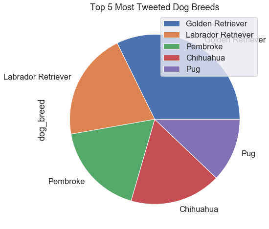

```python
#plotting a pie chart for visualisations
dogs[1:].plot(kind='pie',figsize=(8,8))
plt.title('Top 5 Most Tweeted Dog Breeds')
plt.legend()
```

The Top Five Breeds are Golden Retriever, Labrador Retriever, Pembroke, Chihuahua and Pug

Golden Retriever occupies the first position